# Sweden

Francisco Rios Casas

3/12/2019

# Sweden

### A. Introduction

Sweden is a country in Northern Europe with a population of approximately 10 million people. In its recent history it has undergone many changes from a relatively weak kingdom with many rivals, to a European power with Imperial ambitions, and in the modern era a nation-state with high income, human development, and quality of life. ALthough for the past few centuries, Sweden has maintained an official policy of neutrality from foregin affairs, it has still be heavely ifluenced by the many instances of wars and economic crises in Europe.<sup>1</sup>

### B. Life Expectancy in Sweden

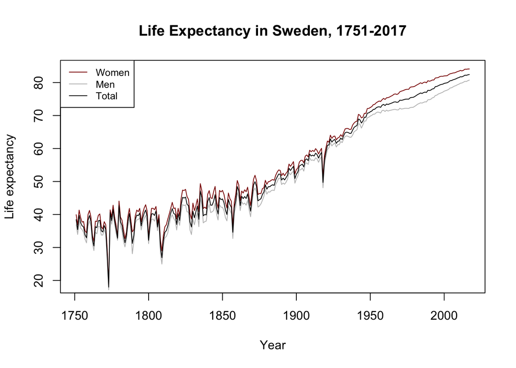

The lowest life expectancy during any time point between 1751 and 2017 was 18.83 years for women and 17.18 years for men.

### C. Population

```r
# run regression on female population size and age
model1 <- lm(Female~Age, data = pop2)
summary(model1)
```

```
##
## Call:
## lm(formula = Female ~ Age, data = pop2)
##
## Residuals:
##     Min      1Q  Median      3Q     Max
## -2688.4 -1107.8   -30.0   763.7  7178.1
##
## Coefficients:
##              Estimate Std. Error t value Pr(>|t|)
## (Intercept) 21417.514    352.236   60.80   <2e-16 ***
## Age          -248.494      7.328  -33.91   <2e-16 ***
## ---
## Signif. codes:  0 '***' 0.001 '**' 0.01 '*' 0.05 '.' 0.1 ' ' 1
##
## Residual standard error: 1629 on 82 degrees of freedom
##   (33816 observations deleted due to missingness)
## Multiple R-squared:  0.9334, Adjusted R-squared:  0.9326
## F-statistic:  1150 on 1 and 82 DF,  p-value: < 2.2e-16
```

```r
library(knitr)
test <- summary(model1)
kable(test$coefficients, caption="Regression Table")
```

Regression Table

|  | Estimate | Std. Error | t value | Pr(>\|t\|) |
| --- | --- | --- | --- | --- |
| (Intercept) | 21417.514 | 352.235520 | 60.80453 | 0 |
| Age | -248.494 | 7.328439 | -33.90818 | 0 |

### C. Data Sources

Data for this report was obtained form the Human Mortality Database, a project of the Department of Demography at the University of California, Berkeley (USA) and at the Max Planck Institute for Demographic Research (MPIDR) in Rostock (Germany). Demographic information for various countries are available for non-commercial use. For further information on where data sources came from see the Human Mortality Database: Sweden Data Sources Page at https://www.mortality.org/hmd/SWE/DOCS/ref.pdf.

### D. References

1. “Sweden” Wikipedia. https://en.wikipedia.org/wiki/Sweden
2. Human Mortality Database. (https://mortality.org)